# Non-Parametric HW

Jami Watson

2025-05-12

```r
head(ChickWeight)
```

```
##   weight Time Chick Diet
## 1     42    0     1    1
## 2     51    2     1    1
## 3     59    4     1    1
## 4     64    6     1    1
## 5     76    8     1    1
## 6     93   10     1    1
```

Wilcoxson Ranked Sign Test Chickens that do not put on weight early in life are most likely to die. Examine the hypothesis that diet 1 will not have an effect on early weight gain of the chicks. Use a non-parametric method for matched pairs.

Null hypothesis= Median difference between weight at t=4 and t=0 from diet 1 is 0. Alternatve hypothesis= Median difference between weight at t=4 and t=0 from diet 1 is not 0.

```r
table(ChickWeight$Diet == 1)
```

```
##
## FALSE  TRUE
##   358   220
```

We have 220 rows in the table for diet 1

```r
df1 <- ChickWeight[ChickWeight$Diet == 1 & ChickWeight$Time %in% c(0,4), ]
```

So df1 contains only the rows from the ChickWeight dataset where the diet is 1 and time is 0 or 4.

```r
head(df1)
```

```
##    weight Time Chick Diet
## 1      42    0     1    1
## 3      59    4     1    1
## 13     40    0     2    1
## 15     58    4     2    1
## 25     43    0     3    1
## 27     55    4     3    1
```

```r
library(tidyr)
wide_data <- pivot_wider(df1,
                         id_cols = Chick,
                         names_from = Time,
                         values_from = weight,
                         names_prefix = "Time_")

wide_data <- na.omit(wide_data)

print(wide_data)
```

```
## # A tibble: 19 × 3
##    Chick Time_0 Time_4
##    <ord>  <dbl>  <dbl>
##  1 1         42     59
##  2 2         40     58
##  3 3         43     55
##  4 4         42     56
##  5 5         41     48
##  6 6         41     59
##  7 7         41     57
##  8 8         42     61
##  9 9         42     59
## 10 10        41     52
## 11 11        43     63
## 12 12        41     56
## 13 13        41     53
## 14 14        41     62
## 15 15        41     56
## 16 16        41     49
## 17 17        42     61
## 18 19        43     55
## 19 20        41     54
```

```r
wilcox.test(wide_data$Time_4, wide_data$Time_0, paired = TRUE, alternative = "two.sided")
```

```
##
##  Wilcoxon signed rank test with continuity correction
##
## data:  wide_data$Time_4 and wide_data$Time_0
## V = 190, p-value = 0.0001412
## alternative hypothesis: true location shift is not equal to 0
```

Now onto the kruskall-wallis test Examine the claim that there is a difference in early weight gain between the different diets. Use a non-parametric method for comparing multiple medians. Be sure to include an appropriate visualization.

Null hypothesis= The median difference between weight at t=4 and t=0 for all of the diets is 0. Alternative hypothesis= The median difference between weight at t=4 and t=0 for all of the diets is not 0.

```r
df3 <- ChickWeight[ChickWeight$Time %in% c(0,4), ]
head(df3)
```

```
##    weight Time Chick Diet
## 1      42    0     1    1
## 3      59    4     1    1
## 13     40    0     2    1
## 15     58    4     2    1
## 25     43    0     3    1
## 27     55    4     3    1
```

```r
library(tidyr)
library(dplyr)
diet_info <- df3 %>%
  filter(Time == 0) %>%
  select(Chick, Diet)

wide_data <- df3 %>%
  pivot_wider(
    id_cols = Chick,
    names_from = Time,
    values_from = weight,
    names_prefix = "Time_"
  )
wide_data <- left_join(wide_data, diet_info, by = "Chick")

wide_data$weight_change <- wide_data$Time_4 - wide_data$Time_0

print(wide_data)
```

```
## # A tibble: 50 × 5
##    Chick Time_0 Time_4 Diet  weight_change
##    <ord>  <dbl>  <dbl> <fct>         <dbl>
##  1 1         42     59 1                17
##  2 2         40     58 1                18
##  3 3         43     55 1                12
##  4 4         42     56 1                14
##  5 5         41     48 1                 7
##  6 6         41     59 1                18
##  7 7         41     57 1                16
##  8 8         42     61 1                19
##  9 9         42     59 1                17
## 10 10        41     52 1                11
## # ℹ 40 more rows
```

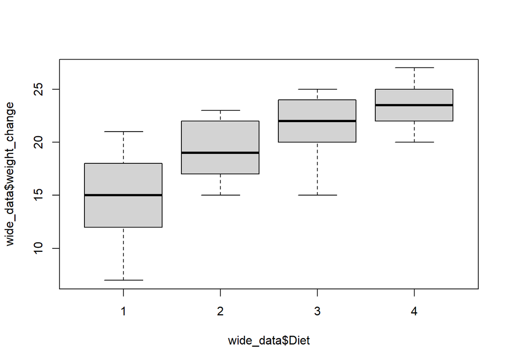

```r
boxplot(wide_data$weight_change ~ wide_data$Diet)
```

```r
by(wide_data$weight_change,wide_data$Diet,median)
```

```
## wide_data$Diet: 1
## [1] NA
## ------------------------------------------------------------
## wide_data$Diet: 2
## [1] 19
## ------------------------------------------------------------
## wide_data$Diet: 3
## [1] 22
## ------------------------------------------------------------
## wide_data$Diet: 4
## [1] 23.5
```

We get NA here for diet 1, this is because chick 18 which was on diet 1, only has values for weight at time 0 and 2. Not a big deal, diet 1 obviously had the least early chick weight gain anyways. However, this may effect our test and we may have to adjust to times 0 and 2 to get a clear look.

```r
kruskal.test(weight_change ~ Diet , data = wide_data)
```

```
##
##  Kruskal-Wallis rank sum test
##
## data:  weight_change by Diet
## Kruskal-Wallis chi-squared = 28.649, df = 3, p-value = 2.653e-06
```

We get a very low p-value so we reject the null hypothesis. The median difference between weight at t=4 and t=0 for all of the diets is not 0. Diet has an effect on early weight gain in chicks. This test was much less of a head ache.